# Aula de laboratório - Diferenças em diferenças

Autor

Rafael Bressan

Data de Publicação

30 de outubro de 2023

```r
library(wooldridge)
library(bacondecomp)
library(did)
library(haven)
library(ggplot2)
library(tidyverse)
library(modelsummary)
library(fixest)
library(lfe)
```

## Diferenças em diferenças (DID)

Modelos DID são atualmente os mais utilizados em estudos observacionais para investigar os efeitos de alguma política em uma variável de interesse. Este tipo de *design* faz uso das variações tanto entre grupo de indivíduos quanto no tempo para obter o **efeito médio do tratamento sobre os tratados** - ATT.

$$\begin{align}
DID &= \underbrace{\mathbb{E}[Y_{ist}|s = \text{NJ}, t = \text{Nov}] - \mathbb{E}[Y_{ist}|s = \text{NJ}, t = \text{Fev}]}_{\Delta_t^{GT}} \\
&- \Big(\underbrace{\mathbb{E}[Y_{ist}|s = \text{PA},t = \text{Nov}] - \mathbb{E}[Y_{ist}| s = \text{PA},t = \text{Fev}]}_{\Delta_t^{GC}}\Big) \\
\end{align}$$

onde estamos fazendo uso do exemplo Card e Krueger (1994). Pensilvânia (PA) é o estado de controle e Nova Jersey (NJ) o grupo tratado.

Em um formato de regressão, o estimador DID é obtido regredindo a variável de interesse em uma *dummy* para o grupo tratamento, uma outra *dummy* para o período após a intervenção e um termo de interação entre os dois, que denota o efetivo tratamento.

$$Y_{st} = \alpha + \beta TRAT_s + \gamma POS_t + \delta(TRAT_s \times POS_t) + \varepsilon_{st}$$

Nesta especificação $\hat\delta = \text{DID}$ e a vantagem de fazer a regressão é que podemos fazer inferência sobre o parâmetro estimado diretamente.

Vamos fazer um exemplo encontrado no livro-texto do Wooldridge, exemplo 13.3 os efeitos de um incinerador de lixo no preço das moradias.

```r
data("kielmc")
# DID manual
tratados <- kielmc[kielmc$nearinc == 1, ]
controles <- kielmc[kielmc$nearinc == 0, ]

delta_t <- mean(tratados[tratados$year == 1981, "rprice"]) -
    mean(tratados[tratados$year == 1978, "rprice"])
delta_c <- mean(controles[controles$year == 1981, "rprice"]) -
    mean(controles[controles$year == 1978, "rprice"])

did_manual <- delta_t - delta_c
```

**Estime o efeito com um DID em forma de regressão**

**Código**

```r
did_reg <- feols(price ~ nearinc * y81,
    data = kielmc,
    vcov = "HC1"
)
etable(did_reg)
```

```
                              did_reg
Dependent Var.:                 price

Constant        82,517.2*** (1,882.4)
nearinc         -18,824.4** (5,996.5)
y81             49,385.2*** (4,275.9)
nearinc x y81   -21,131.8* (10,070.7)
_______________ _____________________
S.E. type       Heteroskedastic.-rob.
Observations                      321
R2                            0.35617
Adj. R2                       0.35008
---
Signif. codes: 0 '***' 0.001 '**' 0.01 '*' 0.05 '.' 0.1 ' ' 1
```

Digamos que a hipótese de tendências paralelas seja válida somente após controlar pela idade do imóvel e idade ao quadrado, distância para uma rodovia, área do terreno e da moradia, número de quartos e banheiros. Gostaríamos também que o modelo fosse especificado em logarítimos, para ter uma ideia de variação percentual do preço da moradia em relação a presença do incinerador.

**Calcule o efeito no cenário acima descrito**

**Código**

```r
did_ctr <- feols(log(rprice) ~ nearinc * y81 + sw0(age + agesq + lintst + log(land) + log(area) + rooms + baths),
    data = kielmc,
    vcov = "HC1"
)

etable(did_ctr)
```

```
                          did_ctr.1            did_ctr.2
Dependent Var.:         log(rprice)          log(rprice)

Constant          11.29*** (0.0251)    7.652*** (0.5262)
nearinc         -0.3399*** (0.0623)      0.0322 (0.0633)
y81              0.1931*** (0.0405)   0.1621*** (0.0272)
nearinc x y81      -0.0626 (0.0947)    -0.1315* (0.0599)
age                                  -0.0084*** (0.0016)
agesq                               3.76e-5*** (1.05e-5)
lintst                                 -0.0614. (0.0350)
log(land)                              0.0998** (0.0328)
log(area)                             0.3508*** (0.0621)
rooms                                  0.0473** (0.0171)
baths                                 0.0943*** (0.0281)
_______________ ___________________ ____________________
S.E. type       Heteroskedast.-rob. Heteroskedasti.-rob.
Observations                    321                  321
R2                          0.24597              0.73256
Adj. R2                     0.23884              0.72394
---
Signif. codes: 0 '***' 0.001 '**' 0.01 '*' 0.05 '.' 0.1 ' ' 1
```

## Diferenças em diferenças com adoção escalonada

Uma literatura recente tem demonstrado que a especificação tradicional de TWFE pode ser viesda para o efeito do tratamento sobre os tratados, ou seja, TWFE com adocação escalonada pode não ser equivalente ao estimador de DID. Vamos utilizar a mesma especificação, porém utilizando o estimador de Callaway & Sant’anna encontrado no pacote [`did`](https://bcallaway11.github.io/did/index.html).

O que é **adoção escalonada ao tratamento**? Casos em que há mais de dois períodos de tempo e unidades diferentes podem ser tratadas em diferentes momentos. Por exemplo, suponha que o tratamento seja a construção de uma rodovia e que a construção da rodovia ocorra em diferentes períodos de tempo para diferentes cidades. Neste caso, a adoção do tratamento é escalonada no tempo e o estimador TWFE tradicional pode ser viesado. Chamamos de coorte as unidades que são inicialmente tratadas no mesmo período de tempo. Outro ponto importante da adoção escalonada é a irreversibilidade do tratamento. Uma vez que uma unidade é tratada, ela não pode voltar a ser não tratada.

**TWFE com múltiplos períodos de tratamento**

$$\begin{equation}
y_{it} =\alpha_i + \gamma_t +\sum_{h=-\infty}^\infty \mu_h \mathbb{I}\{t=g_i+h\} + \varepsilon_{it}, \\
\end{equation}$$

onde $g_i$ é o período de adoção inicial ao tratamento (data que define a coorte) da unidade $i$ e $h$ é o tempo relativo ao tratamento (valores negativos indicam períodos anteriores ao tratamento).

Vamos criar uma base de dados fictícia para entender melhor o tratamento escalonado.

```r
dat4 <- data.frame(
    id = rep(1:3, times = 10),
    tt = rep(1:10, each = 3)
) |>
    within({
        D <- (id == 2 & tt >= 5) | (id == 3 & tt >= 8)
        btrue <- ifelse(D & id == 3, 4, ifelse(D & id == 2, 2, 0))
        y <- id + 1 * tt + btrue * D
    })
```

O gráfico deste conjunto de dados é o seguinte:

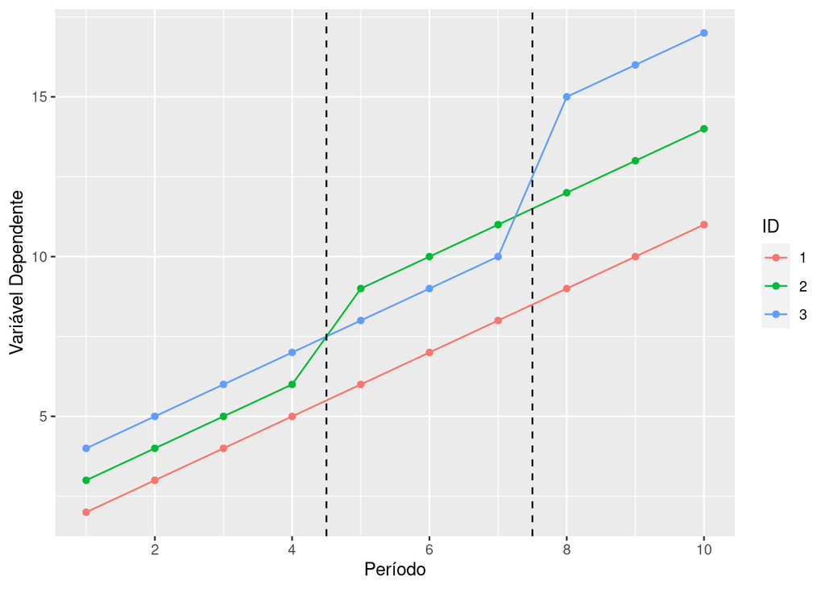

```r
ggplot(dat4, aes(x = tt, y = y, col = factor(id))) +
    geom_point() +
    geom_line() +
    geom_vline(xintercept = c(4.5, 7.5), lty = 2) +
    scale_x_continuous(breaks = scales::pretty_breaks()) +
    labs(x = "Período", y = "Variável Dependente", col = "ID")
```

A decomposição de Goodman-Bacon (2021) é:

```r
(bgd <- bacon(y ~ D, dat4, id_var = "id", time_var = "tt"))
```

```
                      type  weight avg_est
1 Earlier vs Later Treated 0.18182 2.00000
2 Later vs Earlier Treated 0.13636 4.00000
3     Treated vs Untreated 0.68182 2.93333
```

```
  treated untreated estimate    weight                     type
2       5     99999        2 0.3636364     Treated vs Untreated
3       8     99999        4 0.3181818     Treated vs Untreated
6       8         5        4 0.1363636 Later vs Earlier Treated
8       5         8        2 0.1818182 Earlier vs Later Treated
```

Podemos visualizar os quatro DID canônicos que o TWFE está estimando através do gráfico abaixo:

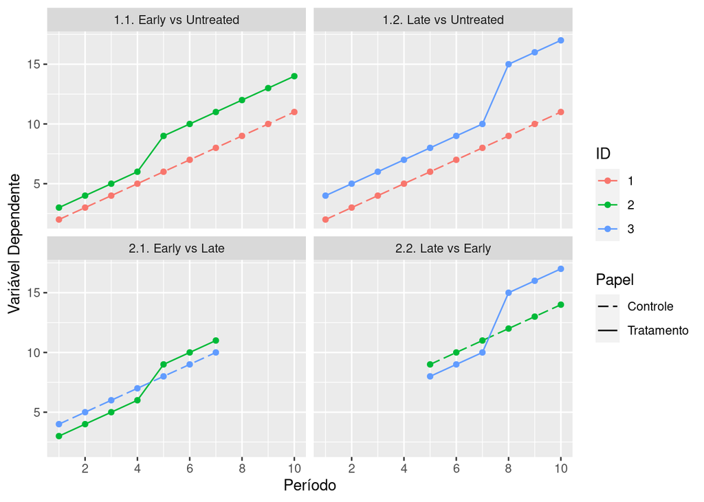

```r
rbind(
    dat4 |> subset(id %in% c(1, 2)) |> transform(role = ifelse(id == 2, "Tratamento", "Controle"), comp = "1.1. Early vs Untreated"),
    dat4 |> subset(id %in% c(1, 3)) |> transform(role = ifelse(id == 3, "Tratamento", "Controle"), comp = "1.2. Late vs Untreated"),
    dat4 |> subset(id %in% c(2, 3) & tt < 8) |> transform(role = ifelse(id == 2, "Tratamento", "Controle"), comp = "2.1. Early vs Late"),
    dat4 |> subset(id %in% c(2:3) & tt > 4) |> transform(role = ifelse(id == 3, "Tratamento", "Controle"), comp = "2.2. Late vs Early")
) |>
    ggplot(aes(tt, y, group = id, col = factor(id), lty = role)) +
    geom_point() +
    geom_line() +
    facet_wrap(~comp) +
    scale_x_continuous(breaks = scales::pretty_breaks()) +
    scale_linetype_manual(values = c("Controle" = 5, "Tratamento" = 1)) +
    labs(x = "Período", y = "Variável Dependente", col = "ID", lty = "Papel")
```

Vamos implementar o exemplo com dados reais encontrado na documentação do pacote [`did`](https://bcallaway11.github.io/did/articles/did-basics.html#an-example-with-real-data). Este é um conjunto de dados que contém as taxas de emprego de adolescentes ao nível do condado de 2003-2007.

```r
data(mpdta)
head(mpdta)
```

```
    year countyreal     lpop     lemp first.treat treat
866 2003       8001 5.896761 8.461469        2007     1
841 2004       8001 5.896761 8.336870        2007     1
842 2005       8001 5.896761 8.340217        2007     1
819 2006       8001 5.896761 8.378161        2007     1
827 2007       8001 5.896761 8.487352        2007     1
937 2003       8019 2.232377 4.997212        2007     1
```

Este é um painel balanceado com 2500 observações ao todo. As coortes $g$ são dadas pela coluna `first.treat` enquanto que o período é dado pela coluna `year` e o grupo tratamento está contido em `treat`. Primeiramente vamos estimar um modelo TWFE dinâmico.

```r
# Cria uma coluna com tempo relativo ao tratamento
mpdta <- mpdta %>%
    mutate(h_period = ifelse(treat == 1, year - first.treat, 0)) # Controles h=0

twfe_reg <- feols(lemp ~ i(h_period, treat, ref = -1) | countyreal + year, data = mpdta)
msummary(twfe_reg)
```

|  | (1) |
| --- | --- |
| h_period = -4 × treat | 0.004 |
|  | (0.023) |
| h_period = -3 × treat | 0.025 |
|  | (0.018) |
| h_period = -2 × treat | 0.023 |
|  | (0.013) |
| h_period = 0 × treat | -0.018 |
|  | (0.011) |
| h_period = 1 × treat | -0.043 |
|  | (0.018) |
| h_period = 2 × treat | -0.132 |
|  | (0.029) |
| h_period = 3 × treat | -0.092 |
|  | (0.032) |
| Num.Obs. | 2500 |
| R2 | 0.993 |
| R2 Adj. | 0.992 |
| R2 Within | 0.010 |
| R2 Within Adj. | 0.007 |
| AIC | -2327.2 |
| BIC | 648.9 |
| RMSE | 0.12 |
| Std.Errors | by: countyreal |
| FE: countyreal | X |
| FE: year | X |

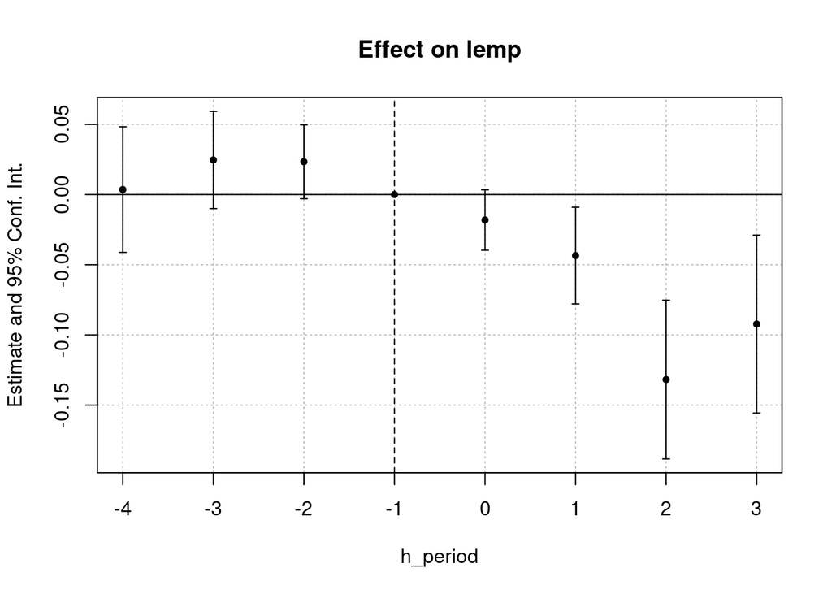

```r
iplot(twfe_reg)
```

Agora, iremos estimar o modelo usando o estimador de Callaway e Sant’Anna (2021).

```r
did_reg <- att_gt(
    yname = "lemp",
    gname = "first.treat",
    idname = "countyreal",
    tname = "year",
    xformla = ~1,
    data = mpdta,
)

did_dyn <- aggte(did_reg, type = "dynamic")
summary(did_dyn)
```

```
Call:
aggte(MP = did_reg, type = "dynamic")

Reference: Callaway, Brantly and Pedro H.C. Sant'Anna.  "Difference-in-Differences with Multiple Time Periods." Journal of Econometrics, Vol. 225, No. 2, pp. 200-230, 2021. <https://doi.org/10.1016/j.jeconom.2020.12.001>, <https://arxiv.org/abs/1803.09015>


Overall summary of ATT's based on event-study/dynamic aggregation:
     ATT    Std. Error     [ 95%  Conf. Int.]
 -0.0772        0.0208     -0.118     -0.0364 *


Dynamic Effects:
 Event time Estimate Std. Error [95% Simult.  Conf. Band]
         -3   0.0305     0.0158       -0.0099      0.0710
         -2  -0.0006     0.0127       -0.0330      0.0319
         -1  -0.0245     0.0149       -0.0625      0.0136
          0  -0.0199     0.0122       -0.0512      0.0113
          1  -0.0510     0.0173       -0.0950     -0.0069 *
          2  -0.1373     0.0380       -0.2342     -0.0403 *
          3  -0.1008     0.0369       -0.1950     -0.0066 *
---
Signif. codes: `*' confidence band does not cover 0

Control Group:  Never Treated,  Anticipation Periods:  0
Estimation Method:  Doubly Robust
```

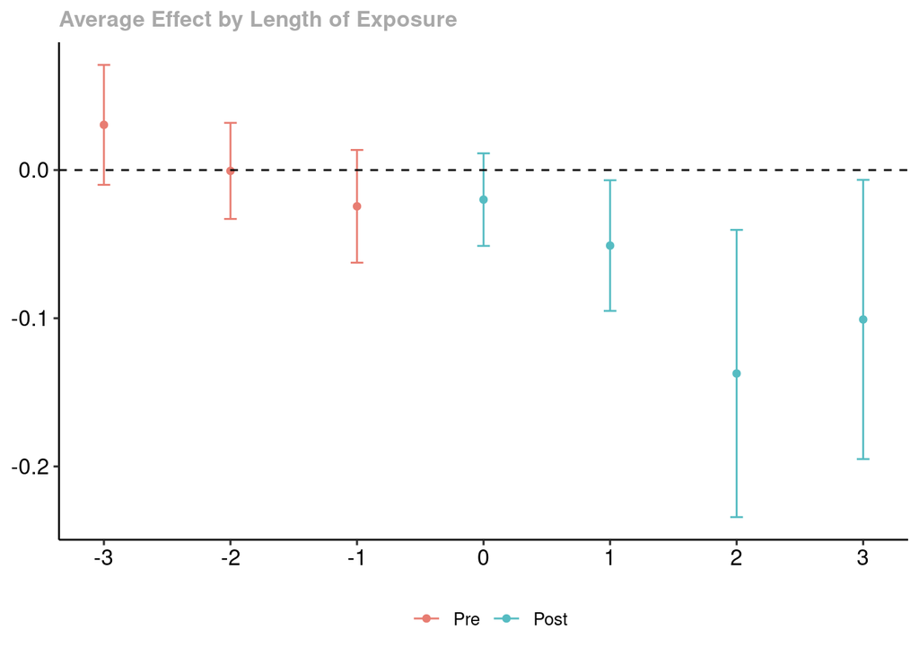

```r
ggdid(did_dyn)
```

Vejam que as estimativas mudaram ligeiramente apenas. Muito embora a especificação TWFE deva ser viesada em teoria, este viés aparentemente é pequeno.

## Referências

Callaway, Brantly, e Pedro HC Sant’Anna. 2021. “Difference-in-differences with multiple time periods”. *Journal of econometrics* 225 (2): 200–230.

Goodman-Bacon, Andrew. 2021. “Difference-in-differences with variation in treatment timing”. *Journal of Econometrics* 225 (2): 254–77. https://doi.org/https://doi.org/10.1016/j.jeconom.2021.03.014.